# Class A Receptor Taxonomical Analysis

Kilicali Isildayancan

25 March 2023

# Taxonomical Analysis

## First look

First we get the TSV file from the UniProt API parser. This file contains names of proteins, their Accession ID, TaxID, Existence, GPCR Domain count, and finally TM count. All is based on UniProt classification.

### Domains

Here, we can see that we have 1788 unique proteins with a minimum of 1 and a maximum of 14 domain hits. The distribution of the number of domain frequencies are as follows:

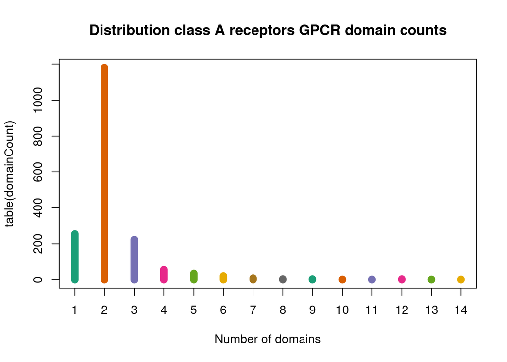

### TM count

The proteins have a 7+ transmembrane domains with a minimum count of 8 and a maximum of 78 domain hits. The distribution of the number of domain frequencies are as follows:

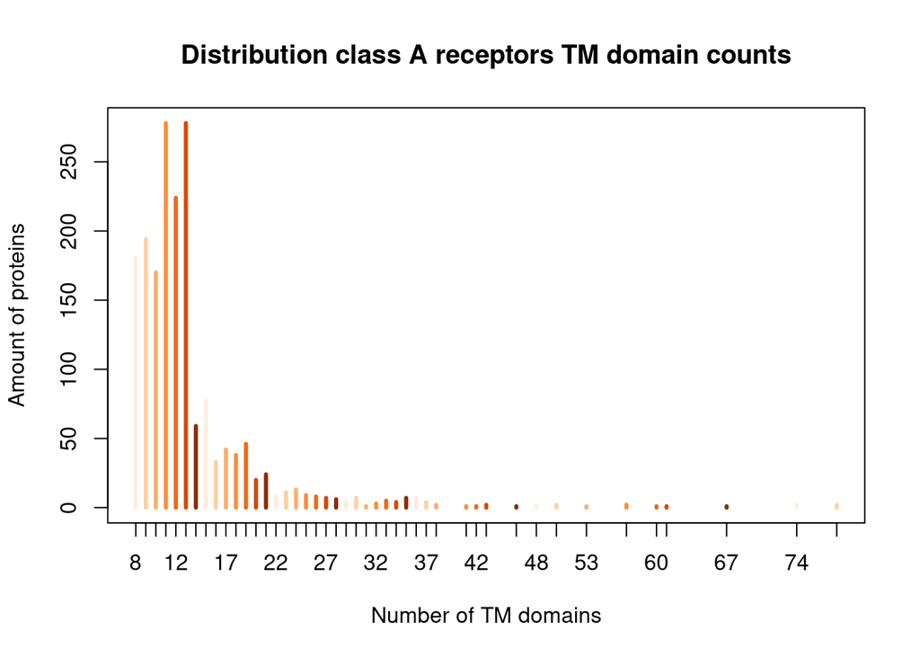

## Specific cases

### Chemokine Receptors

Here are all the “chemokine” annotated receptors (has chemokine in their name). There are 19 receptors that were annotated with chemokine homolgy.

```
##                                            Name AccessionID   TaxID
## 127                chemokine XC receptor 1-like  A0A2I4C1K0   52670
## 160           C-X-C chemokine receptor type 3-2  A0A5C6PHZ4  433684
## 207       Putative chemokine XC receptor 1-like  A0A2U9BIX3   52904
## 295               C-C chemokine receptor type 2  A0A4U5V2I7  240159
## 303           C-X-C chemokine receptor type 3-2  A0A6G0ICJ2  215358
## 325             C-X-C chemokine receptor type 1  A0A3N0Z1Y9  495550
## 357               C-C chemokine receptor type 3  A0A226EJQ2  158441
## 470               C-C chemokine receptor type 2  A0A3N0Y7E2  495550
## 499               C-C chemokine receptor type 5  A0A6B0S3N8   72004
## 543               C-C chemokine receptor type 4  A0A556U1E8  175774
## 561  C-C chemokine receptor type 5-like protein  A0A498MU06   84645
## 609               C-C chemokine receptor type 9      M7BHM6    8469
## 779             C-X-C chemokine receptor type 5      L9KKE8  246437
## 917               C-C chemokine receptor type 7      L9JWP3  246437
```

[output cut: 25 more lines]

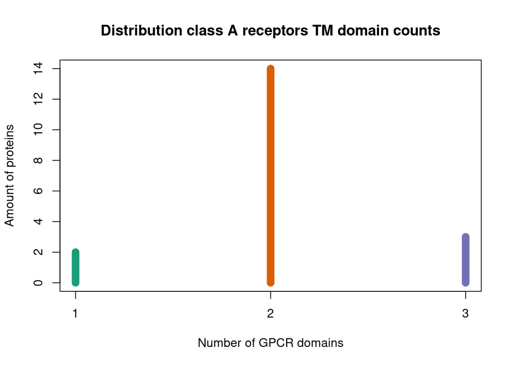

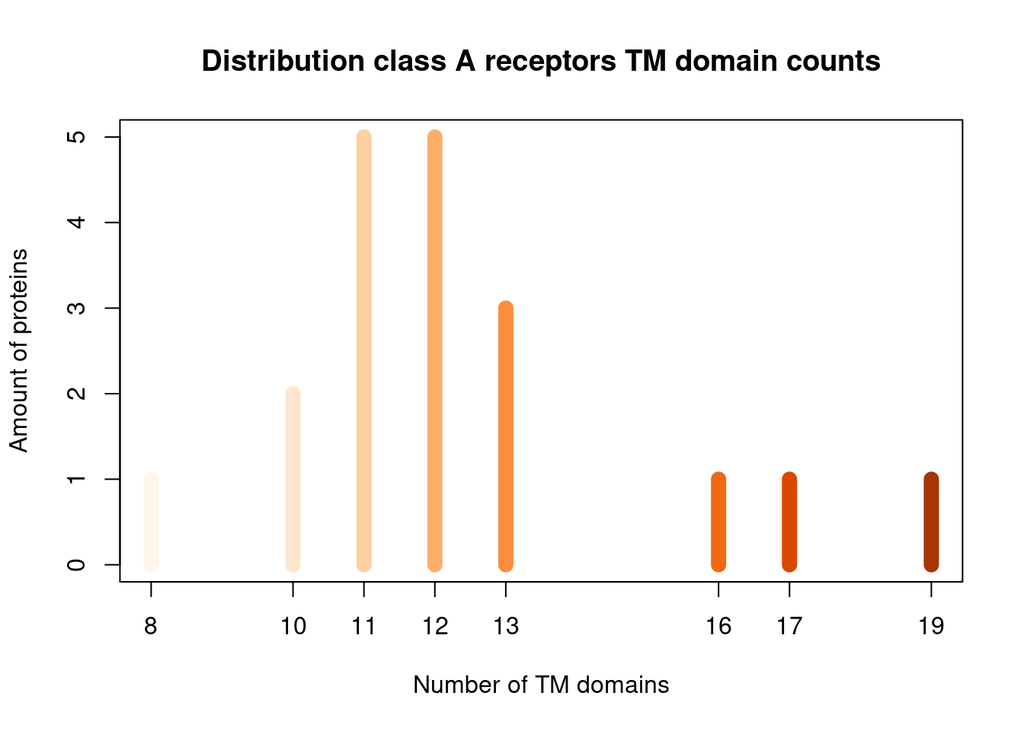

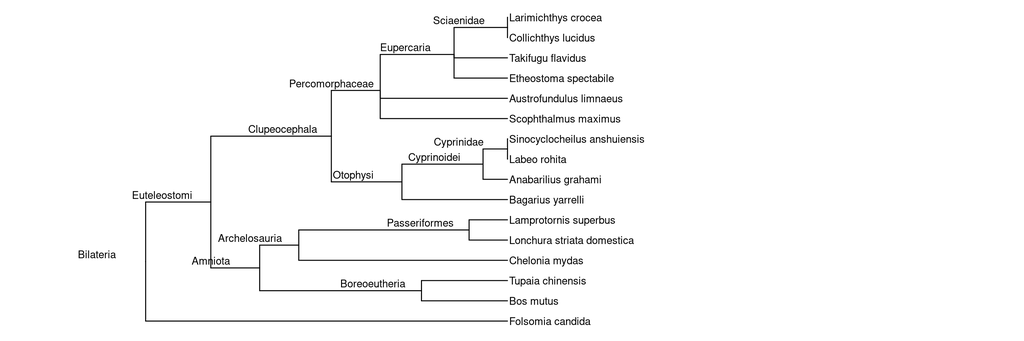

## High-level taxonomy (Superkingdoms, kingdoms, and phylum)

### Superkingdoms

- There are 1 superkingdom(s), namely: Eukaryota. Eukaryotes represent 100% (There are 0 from Bacteria).

### Kingdoms

- There are 1 kingdoms, namely: Metazoa. Here is the distribution:

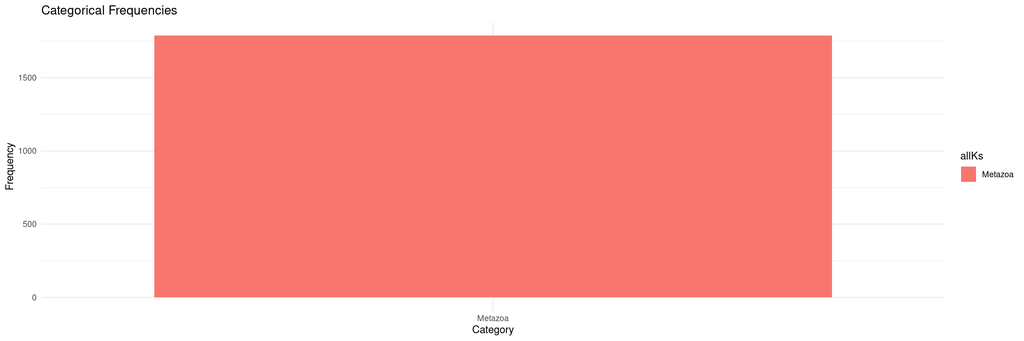

### Phylum

- There are 13 phylums, namely: Chordata, Arthropoda, Cnidaria, Echinodermata, Annelida, Rotifera, Nematoda, Platyhelminthes, Mollusca, Brachiopoda, Placozoa, Tardigrada, Porifera.

Here is a visual representation of all the phylums present (which covers all the lower-level taxa):

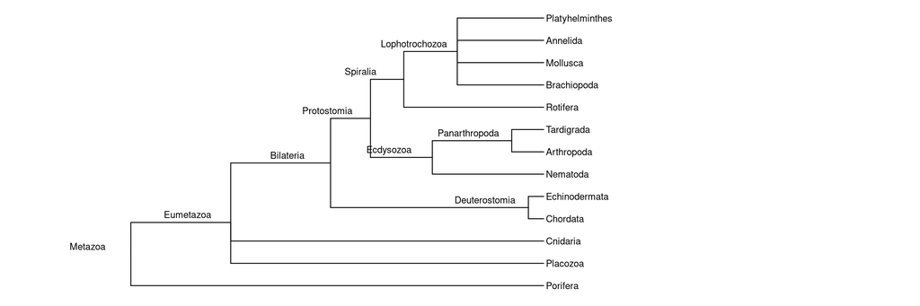

Also the histogram distribution:

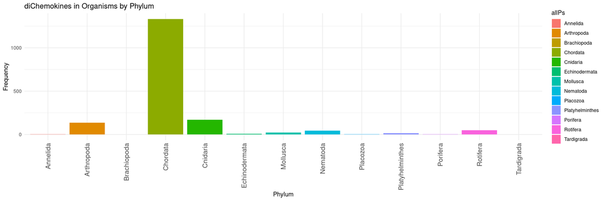

The chordates represent 74.4966443 of all the phylums in the reference proteomes with a total of 1332.

## Mid-level taxonomy (Order)

We are considering only order here, and looking for primates in particular.

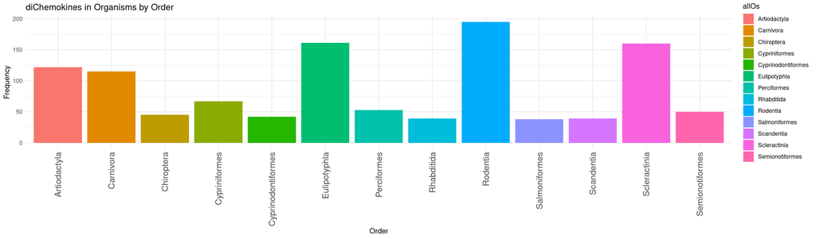

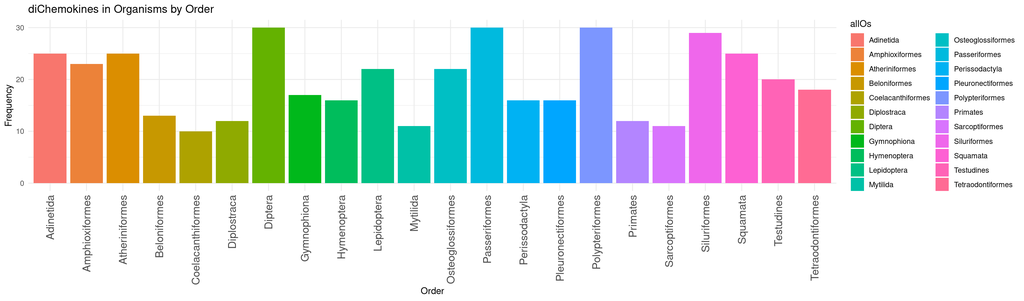

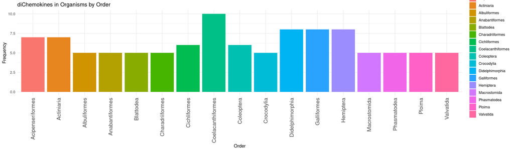

## Low-level taxonomy (Family and Species)

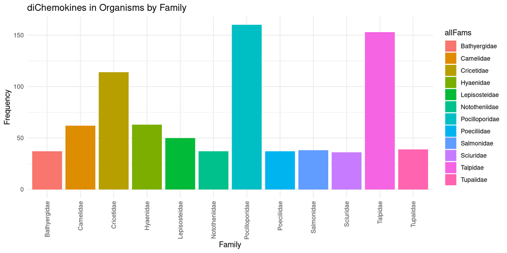

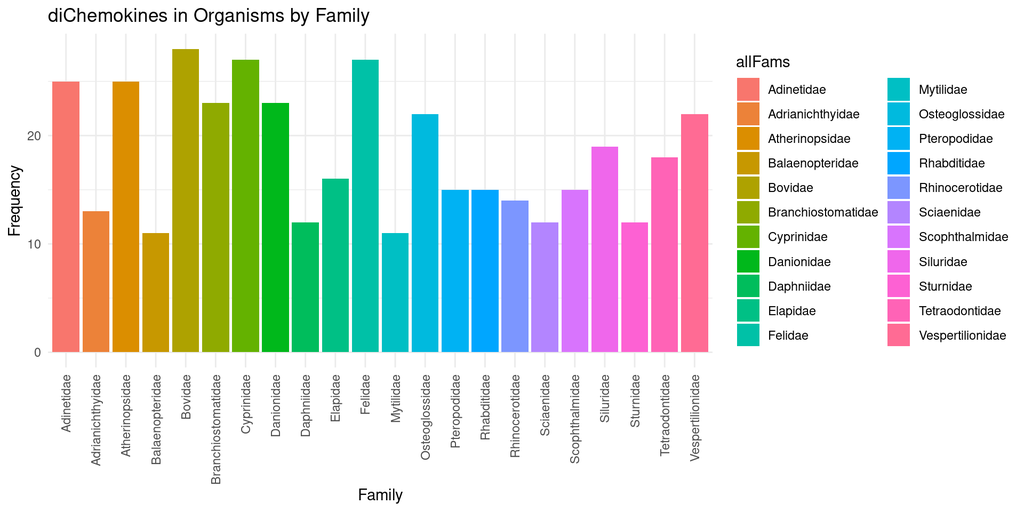

### Cricetidae

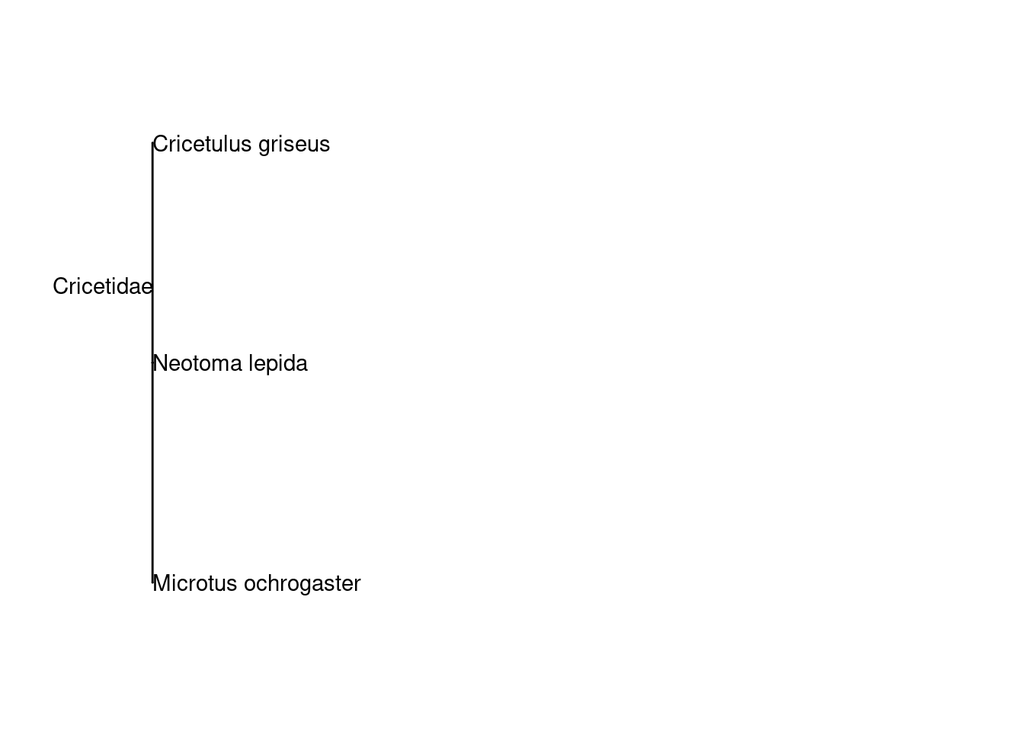

### Families of model organisms

Considered model organisms (and respective orders): if they are in our protein phylogeny

- Mus musculus (Rodentia): TRUE
- Rattus norvegicus (Rodentia): TRUE
- Drosophila melanogaster (Drosophilidae): FALSE
- Bos taurus (Artiodactyla): TRUE
- Callosobruchus maculatus (Coleoptera): TRUE
- Danio rerio (Cypriniformes): TRUE
- Fundulus heteroclitus (Cyprinodontiformes) ~not a “model” : TRUE
- Nothobranchius furzeri (Cyprinodontiformes): TRUE
- Oryzias latipes (Beloniformes): TRUE
- Anolis carolinensis (Squamata): TRUE
- Gallus gallus (Galliformes): TRUE (UPI001F01E243 is in Gallus gallus?)
- Taeniopygia castanotis (Passeriformes): TRUE
- Xenopus laevis (Anura): TRUE
- Xenopus tropicalis (Anura): TRUE
- Saccharomyces cerevisiae (Saccharomycetales): FALSE
- Any primate might be good to start with (Primates): TRUE
- Caenorhabditis elegans (Rhabditida): TRUE
- Strongylocentrotus purpuratus (Echinoida): FALSE

There are low amount of hits in Muridae, but it can be interesting since it has Rattus and Mus in it as geni (mice and rats as model organisms)